# Stat_project_3

Someone

2/20/2020

# Abstract: Expression levels of 77 proteins measured in the cerebral cortex of 8 classes of control and Down syndrome mice exposed to context fear conditioning, a task used to assess associative learning.

```r
path = './data/Data_Cortex_Nuclear.csv'
data <- read.csv(path,na.strings = '', sep='\t')
str(data)
```

```
## 'data.frame':    1080 obs. of  82 variables:
##  $ MouseID        : Factor w/ 1080 levels "18899_1","18899_10",..: 46 53 54 55 56 57 58 59 60 47 ...
##  $ DYRK1A_N       : num  0.504 0.515 0.509 0.442 0.435 ...
##  $ ITSN1_N        : num  0.747 0.689 0.73 0.617 0.617 ...
##  $ BDNF_N         : num  0.43 0.412 0.418 0.359 0.359 ...
##  $ NR1_N          : num  2.82 2.79 2.69 2.47 2.37 ...
##  $ NR2A_N         : num  5.99 5.69 5.62 4.98 4.72 ...
##  $ pAKT_N         : num  0.219 0.212 0.209 0.223 0.213 ...
##  $ pBRAF_N        : num  0.178 0.173 0.176 0.176 0.174 ...
##  $ pCAMKII_N      : num  2.37 2.29 2.28 2.15 2.13 ...
##  $ pCREB_N        : num  0.232 0.227 0.23 0.207 0.192 ...
##  $ pELK_N         : num  1.75 1.6 1.56 1.6 1.5 ...
##  $ pERK_N         : num  0.688 0.695 0.677 0.583 0.551 ...
##  $ pJNK_N         : num  0.306 0.299 0.291 0.297 0.287 ...
##  $ PKCA_N         : num  0.403 0.386 0.381 0.377 0.364 ...
```

[output cut: 68 more lines]

Basic description by columns 1 Mouse ID 2..78 Values of expression levels of 77 proteins; the names of proteins are followed by indicating that they were measured in the nuclear fraction. For example: DYRK1A_n 79 Genotype: control (c) or trisomy (t) 80 Treatment type: memantine (m) or saline (s) 81 Behavior: context-shock (CS) or shock-context (SC) 82 Class: c-CS-s, c-CS-m, c-SC-s, c-SC-m, t-CS-s, t-CS-m, t-SC-s, t-SC-m

We can see that variable **class** consist of all other variables and we haven’t any problem with our factor variables.

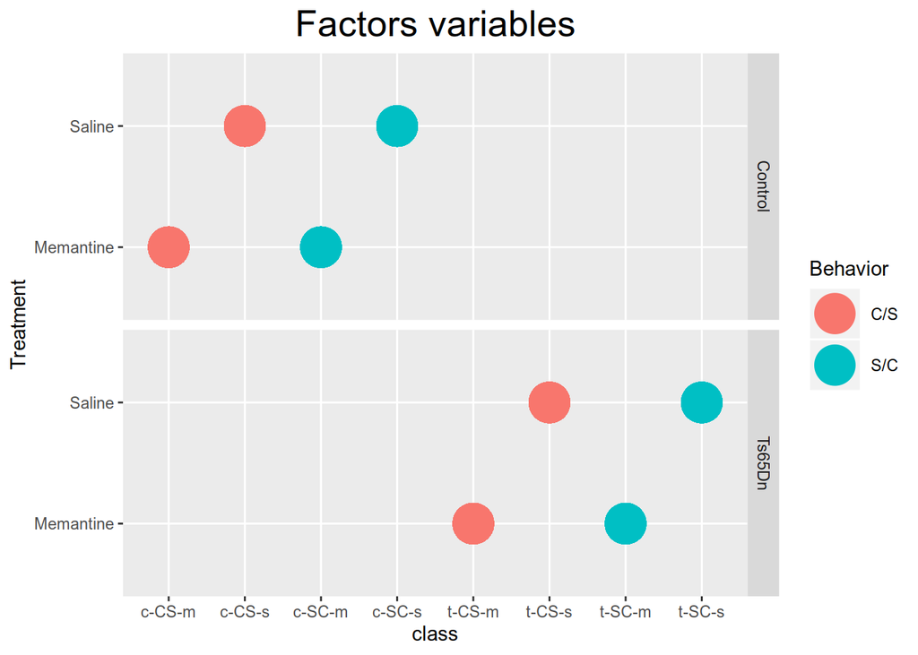

```r
ggplot(data, aes(x = class, y = Treatment)) +
  geom_point(aes(color=Behavior), size = 10) +
  facet_grid(Genotype~.) + # visualisng our groups based on factors levels
  ggtitle('Factors variables') +
    theme(plot.title = element_text(hjust = 0.5, size = 20))
```

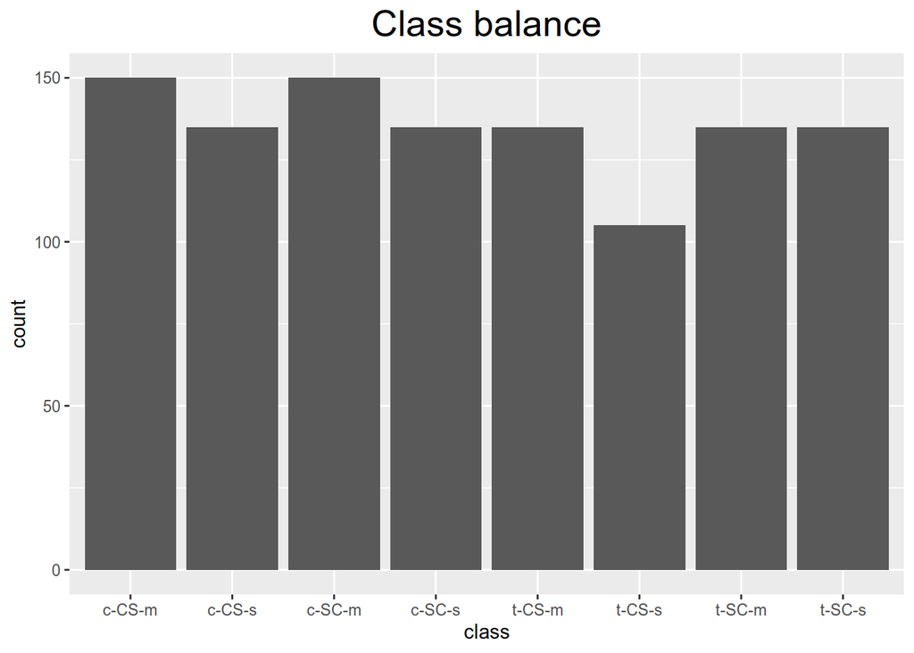

```r
ggplot(data, aes(x=class)) +
  geom_histogram(stat='count', na.rm = TRUE) +
  ggtitle('Class balance') +
    theme(plot.title = element_text(hjust = 0.5, size = 20))
```

Let’s check it in our dataset:

```r
paste('Number of mouse in experiment:', length(unique(gsub('(.*)_.*','\\1', data$MouseID)))) # So there are 72 mouses here
```

```
## [1] "Number of mouse in experiment: 72"
```

```r
# lets check NA values in our protein data:
data_noNA <- na.omit(data)
paste('Number of samples without any NA:', nrow(data_noNA))# we have 552 obs without any NA
```

```
## [1] "Number of samples without any NA: 552"
```

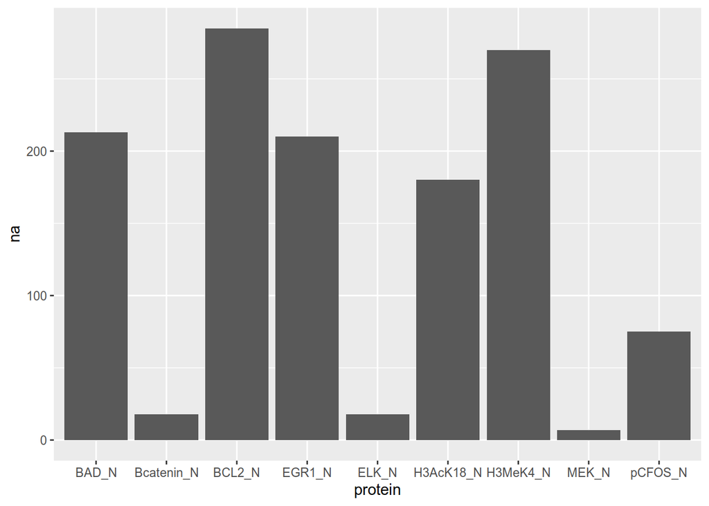

```r
# data_group <- data %>% group_by(MouseID,Genotype,Treatment,Behavior,class) %>% summarise()
countNA <- apply(data,2 , function(x) length(x[is.na(x)]))
countNAdf <- data.frame(na = countNA, protein = names(countNA))
countNAdf <- countNAdf[countNAdf$na > 3,]  # remove protein with several NA's
ggplot(data = countNAdf,aes(x = protein, y = na)) + geom_col()
```

But half rows of our datatset have NA values and that is a real problem! In addition, five proteins: BAD_N, BCL2_N, H3AcK18_N, EGR1_N, H3MeK4_N have about 20% of NA values. First of all let’s remove proteins with too much NA values. And then let’s try to do something with another NA values.

```r
data_f <- data %>% select_if(!(colnames(.) %in% rownames(countNAdf[countNAdf$na > 150, ])))# first of all let's remove protein with > 15% NA values

data_noNA <- data_f %>% group_by(class) %>% mutate_all(funs(ifelse(is.na(.),mean(.,na.rm=TRUE),.)))
```

```
## `mutate_all()` ignored the following grouping variables:
## Column `class`
## Use `mutate_at(df, vars(-group_cols()), myoperation)` to silence the message.
```

```r
# exchange NA on mean of each class
```

We exchanged NA values on mean of each class, it’s a good desicion because we removed variables with a lot of NA.

Let’s compare BDNF_N expression in different classes. First of all, let’s look on data:

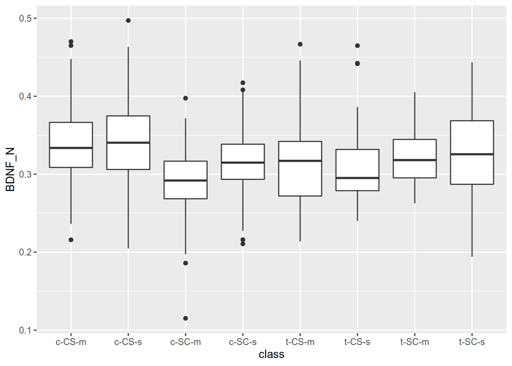

```r
ggplot(data_noNA,aes(y=BDNF_N, x=class)) + geom_boxplot()
```

We see that level of expression in different classes is approximately identical. Let’s check it with power of statistic! For this tasks we want to use ANOVA, but to use it, we need the normality of the sample and the homogeneity of the variance. Let’s check it:

```r
normORnot <- group_by(data_noNA, class) %>% summarise(normORnot = shapiro.test(BDNF_N)$p.value)
normORnot
```

```
## # A tibble: 8 x 2
##   class  normORnot
##   <fct>      <dbl>
## 1 c-CS-m 0.111
## 2 c-CS-s 0.549
## 3 c-SC-m 0.000704
## 4 c-SC-s 0.153
## 5 t-CS-m 0.0154
## 6 t-CS-s 0.0000139
## 7 t-SC-m 0.00463
## 8 t-SC-s 0.231
```

The expression level of our protein is not distributed normally. Really bad, but ANOVA can handle it. Then we need to check homogenity of variance.

```r
bdnf_vector <- data_noNA$BDNF_N
names(bdnf_vector) <- data_noNA$class
levene.test(bdnf_vector, c(rep('c-CS-m',150),
                           rep('c-CS-s',135),
                           rep('c-SC-m',150),
                           rep('c-SC-s',135),
                           rep('t-CS-m',135),
                           rep('t-CS;s',105),
                           rep('t-SC-m',135),
                           rep('t-SC-s',135)))
```

```
##
##  Modified robust Brown-Forsythe Levene-type test based on the absolute
##  deviations from the median
##
## data:  bdnf_vector
## Test Statistic = 7.2216, p-value = 1.802e-08
```

So we have p-value of Levene’s test << 0.05. This tells us that we haven’t homogenity of variances and we can’t use ANOVA =C *In addition we have different numbers of values in each class, it’s really sad for ANOVA.

Let’s use non-parametric criteria. Kruskal — Wallis is non-parametric rank criteria based on a comparison of medians of samples.

```r
kruskal.test(data_noNA$BDNF_N, data$class)
```

```
##
##  Kruskal-Wallis rank sum test
##
## data:  data_noNA$BDNF_N and data$class
## Kruskal-Wallis chi-squared = 121.29, df = 7, p-value < 2.2e-16
```

The pvalue << 0.05 tells us that expression of BDNF_N in different classes differ significantly! Let’s find out which groups are different. To do this, we use Tukey test (pairwise comparisons).

```r
turkey_test <- TukeyHSD(aov(BDNF_N~class, data=data_noNA), ordered=TRUE)
df <- data.frame(turkey_test$class, classes = rownames(turkey_test$class))
df_f <- df %>% filter(`p.adj` < 0.05)
df_f[,c("classes","p.adj")]
```

```
##          classes        p.adj
## 1  t-CS-m-c-SC-m 2.258840e-03
## 2  c-SC-s-c-SC-m 1.397275e-03
## 3  t-SC-m-c-SC-m 1.850318e-06
## 4  t-SC-s-c-SC-m 1.603605e-08
## 5  c-CS-m-c-SC-m 0.000000e+00
## 6  c-CS-s-c-SC-m 0.000000e+00
## 7  t-SC-s-t-CS-s 2.131978e-02
## 8  c-CS-m-t-CS-s 4.747394e-07
## 9  c-CS-s-t-CS-s 5.031518e-08
## 10 c-CS-m-t-CS-m 5.383381e-05
## 11 c-CS-s-t-CS-m 6.375219e-06
## 12 c-CS-m-c-SC-s 9.507174e-05
## 13 c-CS-s-c-SC-s 1.163387e-05
## 14 c-CS-m-t-SC-m 2.389551e-02
## 15 c-CS-s-t-SC-m 4.769310e-03
```

Here we see which classes differ in the level of protein BDNF_N expression

# Linear model for prediction of expression level of ERBB4_N protein based on values of expression of other protein.

```r
data_lm <- data_noNA[-c(1,77,76,75,74)]
fit <- lm(ERBB4_N ~., data_lm)
summary(fit)
```

```
##
## Call:
## lm(formula = ERBB4_N ~ ., data = data_lm)
##
## Residuals:
##       Min        1Q    Median        3Q       Max
## -0.025663 -0.003989 -0.000048  0.003639  0.037809
##
## Coefficients: (1 not defined because of singularities)
##                   Estimate Std. Error t value Pr(>|t|)
## (Intercept)      2.593e-02  5.619e-03   4.615 4.44e-06 ***
## DYRK1A_N        -7.899e-03  5.441e-03  -1.452 0.146881
## ITSN1_N          1.322e-02  5.936e-03   2.227 0.026137 *
## BDNF_N          -3.905e-03  1.419e-02  -0.275 0.783259
## NR1_N           -6.949e-03  3.817e-03  -1.821 0.068951 .
## NR2A_N           3.114e-04  9.784e-04   0.318 0.750379
## pAKT_N           3.437e-02  1.444e-02   2.380 0.017518 *
## pBRAF_N         -4.298e-02  2.217e-02  -1.939 0.052811 .
## pCAMKII_N       -2.181e-05  4.533e-04  -0.048 0.961636
## pCREB_N         -4.342e-02  1.999e-02  -2.172 0.030080 *
## pELK_N          -7.887e-04  9.706e-04  -0.813 0.416643
## pERK_N          -1.706e-03  2.639e-03  -0.647 0.518075
## pJNK_N          -3.932e-02  1.643e-02  -2.393 0.016910 *
## PKCA_N           4.496e-02  1.561e-02   2.879 0.004074 **
## pMEK_N          -6.756e-03  1.630e-02  -0.414 0.678602
## pNR1_N          -1.819e-02  8.916e-03  -2.041 0.041560 *
## pNR2A_N          3.983e-03  4.369e-03   0.912 0.362122
## pNR2B_N          4.514e-03  3.796e-03   1.189 0.234686
## pPKCAB_N         1.524e-03  1.889e-03   0.806 0.420147
## pRSK_N           1.227e-02  8.747e-03   1.403 0.160823
## AKT_N            9.929e-03  5.961e-03   1.666 0.096110 .
## BRAF_N          -1.227e-02  6.769e-03  -1.813 0.070167 .
## CAMKII_N         2.753e-02  1.323e-02   2.080 0.037782 *
## CREB_N          -2.083e-02  1.995e-02  -1.044 0.296707
## ELK_N            2.652e-03  2.622e-03   1.011 0.312140
## ERK_N            4.195e-03  1.632e-03   2.571 0.010289 *
## GSK3B_N          3.713e-03  4.003e-03   0.928 0.353811
## JNK_N            3.238e-03  2.069e-02   0.157 0.875657
## MEK_N            4.781e-03  1.405e-02   0.340 0.733713
## TRKA_N           1.254e-03  8.611e-03   0.146 0.884206
```

[output cut: 33 more lines]

```
## PSD95_N          1.801e-02  2.084e-03   8.639  < 2e-16 ***
## SNCA_N           2.010e-02  2.360e-02   0.852 0.394535
## Ubiquitin_N     -1.343e-04  3.314e-03  -0.041 0.967689
## pGSK3B_Tyr216_N  2.226e-02  6.500e-03   3.425 0.000640 ***
## SHH_N            7.275e-03  1.282e-02   0.568 0.570442
## pS6_N                   NA         NA      NA       NA
## pCFOS_N         -4.812e-02  1.651e-02  -2.915 0.003633 **
## SYP_N            2.021e-02  6.300e-03   3.207 0.001383 **
## CaNA_N          -6.860e-03  2.397e-03  -2.861 0.004304 **
## ---
## Signif. codes:  0 '***' 0.001 '**' 0.01 '*' 0.05 '.' 0.1 ' ' 1
##
## Residual standard error: 0.006684 on 1009 degrees of freedom
## Multiple R-squared:  0.8161, Adjusted R-squared:  0.8033
## F-statistic: 63.95 on 70 and 1009 DF,  p-value: < 2.2e-16
```

```r
  # ggplot(fit,aes(fit$residuals))+ geom_histogram(bin = 30, color = "black", fill = "purple4") +
# theme(panel.background = element_rect(fill = "white"),
# axis.line.x=element_line(),
# axis.line.y=element_line()) +
# ggtitle("Histogram for Model Residuals")
```

Let’s choose most significantly predictors!

```r
step <- stepAIC(fit, direction="both")
```

[output not shown]

[output cut: 2568 more lines]

```
## - AcetylH3K9_N     1 0.0004194 0.045980 -10789
## - pJNK_N           1 0.0004240 0.045984 -10789
## - IL1B_N           1 0.0004769 0.046037 -10788
## - CaNA_N           1 0.0005631 0.046123 -10786
## - ERK_N            1 0.0006244 0.046185 -10785
## - SYP_N            1 0.0007453 0.046306 -10782
## - MTOR_N           1 0.0008133 0.046374 -10780
## - PKCA_N           1 0.0008518 0.046412 -10779
## - Tau_N            1 0.0010745 0.046635 -10774
## - pGSK3B_Tyr216_N  1 0.0011502 0.046711 -10772
## - ARC_N            1 0.0012117 0.046772 -10771
## - pPKCG_N          1 0.0022646 0.047825 -10747
## - pCASP9_N         1 0.0023055 0.047866 -10746
## - P3525_N          1 0.0025520 0.048112 -10740
## - PSD95_N          1 0.0041707 0.049731 -10705
```

```r
step$anova # display results
```

```
## Stepwise Model Path
## Analysis of Deviance Table
##
## Initial Model:
## ERBB4_N ~ DYRK1A_N + ITSN1_N + BDNF_N + NR1_N + NR2A_N + pAKT_N +
##     pBRAF_N + pCAMKII_N + pCREB_N + pELK_N + pERK_N + pJNK_N +
##     PKCA_N + pMEK_N + pNR1_N + pNR2A_N + pNR2B_N + pPKCAB_N +
##     pRSK_N + AKT_N + BRAF_N + CAMKII_N + CREB_N + ELK_N + ERK_N +
##     GSK3B_N + JNK_N + MEK_N + TRKA_N + RSK_N + APP_N + Bcatenin_N +
##     SOD1_N + MTOR_N + P38_N + pMTOR_N + DSCR1_N + AMPKA_N + NR2B_N +
##     pNUMB_N + RAPTOR_N + TIAM1_N + pP70S6_N + NUMB_N + P70S6_N +
##     pGSK3B_N + pPKCG_N + CDK5_N + S6_N + ADARB1_N + AcetylH3K9_N +
##     RRP1_N + BAX_N + ARC_N + nNOS_N + Tau_N + GFAP_N + GluR3_N +
##     GluR4_N + IL1B_N + P3525_N + pCASP9_N + PSD95_N + SNCA_N +
##     Ubiquitin_N + pGSK3B_Tyr216_N + SHH_N + pS6_N + pCFOS_N +
##     SYP_N + CaNA_N
##
## Final Model:
## ERBB4_N ~ DYRK1A_N + ITSN1_N + NR1_N + pAKT_N + pBRAF_N + pCREB_N +
##     pJNK_N + PKCA_N + pNR1_N + pNR2B_N + pRSK_N + AKT_N + BRAF_N +
##     CAMKII_N + ERK_N + RSK_N + SOD1_N + MTOR_N + pMTOR_N + TIAM1_N +
##     NUMB_N + P70S6_N + pGSK3B_N + pPKCG_N + CDK5_N + AcetylH3K9_N +
##     RRP1_N + ARC_N + Tau_N + GFAP_N + GluR3_N + GluR4_N + IL1B_N +
##     P3525_N + pCASP9_N + PSD95_N + pGSK3B_Tyr216_N + pCFOS_N +
##     SYP_N + CaNA_N
##
##
##             Step Df     Deviance Resid. Df Resid. Dev       AIC
## 1                                     1009 0.04507661 -10748.84
## 2        - pS6_N  0 0.000000e+00      1009 0.04507661 -10748.84
## 3  - Ubiquitin_N  1 7.333806e-08      1010 0.04507669 -10750.83
## 4   - Bcatenin_N  1 7.853725e-08      1011 0.04507677 -10752.83
## 5    - pCAMKII_N  1 2.388326e-07      1012 0.04507700 -10754.83
## 6         - S6_N  1 3.526189e-07      1013 0.04507736 -10756.82
## 7        - P38_N  1 3.973999e-07      1014 0.04507775 -10758.81
## 8        - BAX_N  1 4.516269e-07      1015 0.04507821 -10760.80
## 9       - TRKA_N  1 6.136960e-07      1016 0.04507882 -10762.78
## 10       - JNK_N  1 1.177448e-06      1017 0.04508000 -10764.76
## 11      - NR2B_N  1 2.603689e-06      1018 0.04508260 -10766.69
## 12      - BDNF_N  1 2.560300e-06      1019 0.04508516 -10768.63
## 13      - NR2A_N  1 5.012432e-06      1020 0.04509017 -10770.51
## 14      - pMEK_N  1 6.430209e-06      1021 0.04509660 -10772.36
## 15       - MEK_N  1 5.229254e-06      1022 0.04510183 -10774.23
## 16       - APP_N  1 6.068609e-06      1023 0.04510790 -10776.09
## 17     - DSCR1_N  1 7.351374e-06      1024 0.04511525 -10777.91
## 18      - nNOS_N  1 1.136563e-05      1025 0.04512662 -10779.64
## 19     - pNUMB_N  1 1.093542e-05      1026 0.04513755 -10781.38
## 20    - pP70S6_N  1 1.927805e-05      1027 0.04515683 -10782.92
## 21      - SNCA_N  1 1.636415e-05      1028 0.04517320 -10784.53
## 22       - SHH_N  1 2.026544e-05      1029 0.04519346 -10786.04
## 23      - pERK_N  1 2.448593e-05      1030 0.04521795 -10787.46
## 24     - GSK3B_N  1 3.774826e-05      1031 0.04525570 -10788.55
## 25    - ADARB1_N  1 2.685390e-05      1032 0.04528255 -10789.91
## 26     - pNR2A_N  1 1.859700e-05      1033 0.04530115 -10791.47
## 27      - pELK_N  1 4.543264e-05      1034 0.04534658 -10792.39
## 28    - pPKCAB_N  1 4.006181e-05      1035 0.04538664 -10793.43
## 29     - AMPKA_N  1 4.623924e-05      1036 0.04543288 -10794.33
## 30    - RAPTOR_N  1 2.139969e-05      1037 0.04545428 -10795.83
## 31       - ELK_N  1 4.391359e-05      1038 0.04549819 -10796.78
## 32      - CREB_N  1 6.209226e-05      1039 0.04556029 -10797.31
```

Let’s make a diagnosis of our resulting model What about residues?

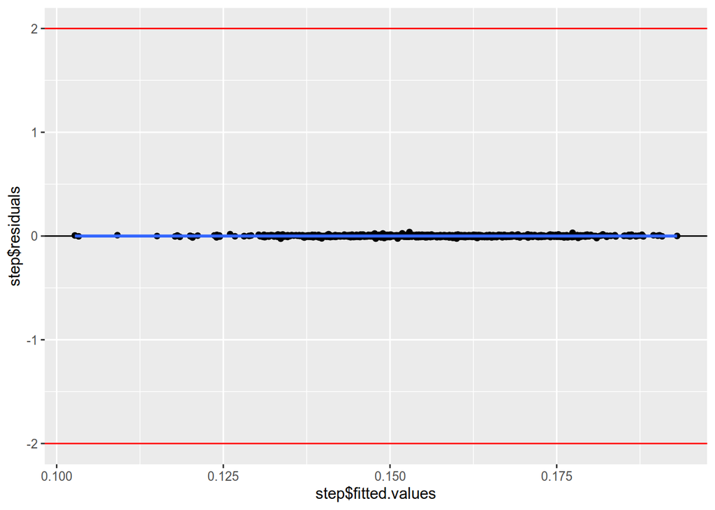

```r
  gg_resid <- ggplot(data = step, aes(x = step$fitted.values, y = step$residuals)) +
  geom_point() +
  geom_hline(yintercept = 0) +
  geom_smooth(method = "lm") +
  geom_hline(yintercept = 2, color = "red") +
  geom_hline(yintercept = -2, color = "red")
gg_resid
```

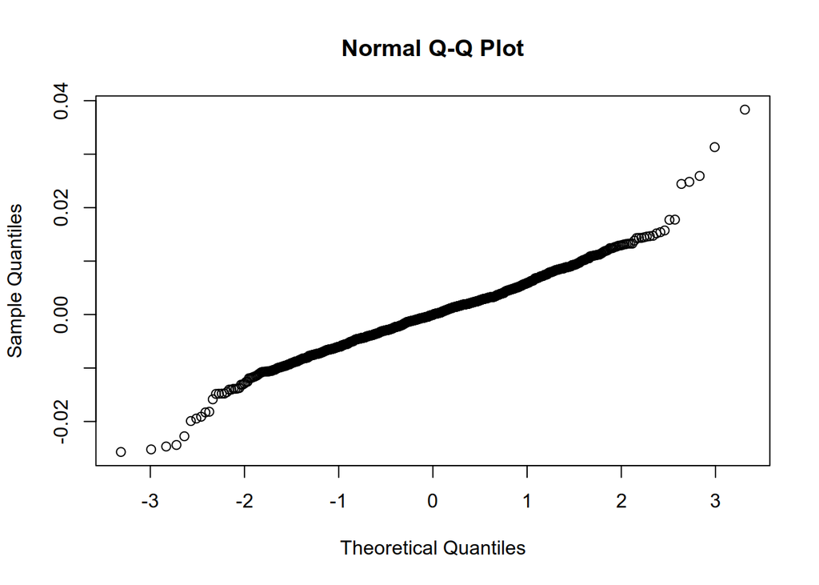

```r
qqnorm(step$residuals)
```

```r
shapiro.test(step$residuals) # balances are not distributed normally
```

```
##
##  Shapiro-Wilk normality test
##
## data:  step$residuals
## W = 0.97848, p-value = 1.431e-11
```

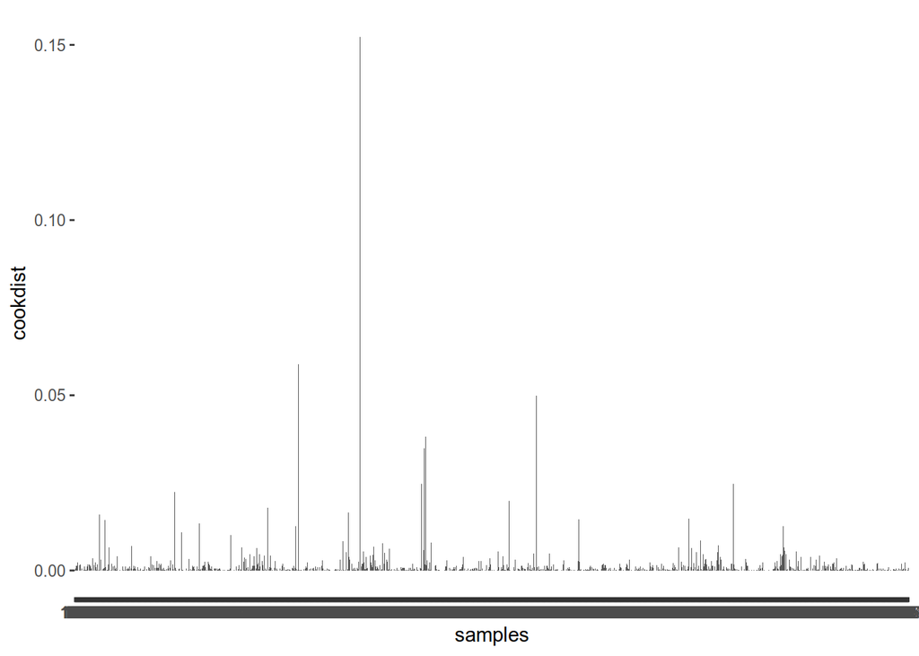

```r
cookies <- cooks.distance(step)

cookies_df <- data.frame(cookdist = cookies, samples = names(cookies))
ggplot(cookies_df, aes(y= cookdist, x= samples)) + geom_bar(stat = "identity")
```

```r
summary(step)
```

```
##
## Call:
## lm(formula = ERBB4_N ~ DYRK1A_N + ITSN1_N + NR1_N + pAKT_N +
##     pBRAF_N + pCREB_N + pJNK_N + PKCA_N + pNR1_N + pNR2B_N +
##     pRSK_N + AKT_N + BRAF_N + CAMKII_N + ERK_N + RSK_N + SOD1_N +
##     MTOR_N + pMTOR_N + TIAM1_N + NUMB_N + P70S6_N + pGSK3B_N +
##     pPKCG_N + CDK5_N + AcetylH3K9_N + RRP1_N + ARC_N + Tau_N +
##     GFAP_N + GluR3_N + GluR4_N + IL1B_N + P3525_N + pCASP9_N +
##     PSD95_N + pGSK3B_Tyr216_N + pCFOS_N + SYP_N + CaNA_N, data = data_lm)
##
## Residuals:
##       Min        1Q    Median        3Q       Max
## -0.025702 -0.003954 -0.000044  0.003539  0.038329
##
## Coefficients:
##                   Estimate Std. Error t value Pr(>|t|)
## (Intercept)      0.0241232  0.0048915   4.932 9.49e-07 ***
## DYRK1A_N        -0.0101018  0.0048530  -2.082 0.037629 *
## ITSN1_N          0.0138229  0.0049116   2.814 0.004980 **
## NR1_N           -0.0076720  0.0033633  -2.281 0.022744 *
## pAKT_N           0.0320031  0.0128583   2.489 0.012969 *
## pBRAF_N         -0.0485562  0.0192264  -2.525 0.011701 *
## pCREB_N         -0.0403264  0.0151867  -2.655 0.008043 **
## pJNK_N          -0.0350273  0.0112646  -3.109 0.001925 **
## PKCA_N           0.0520423  0.0118077   4.408 1.15e-05 ***
## pNR1_N          -0.0142076  0.0078409  -1.812 0.070276 .
## pNR2B_N          0.0064882  0.0026316   2.465 0.013844 *
## pRSK_N           0.0112561  0.0070224   1.603 0.109265
## AKT_N            0.0107939  0.0044455   2.428 0.015348 *
## BRAF_N          -0.0114348  0.0054310  -2.105 0.035489 *
## CAMKII_N         0.0258542  0.0112571   2.297 0.021834 *
## ERK_N            0.0042545  0.0011275   3.774 0.000170 ***
## RSK_N            0.0295597  0.0210763   1.403 0.161062
## SOD1_N          -0.0020238  0.0013240  -1.529 0.126683
## MTOR_N           0.0375724  0.0087245   4.307 1.82e-05 ***
## pMTOR_N         -0.0105894  0.0044261  -2.392 0.016912 *
## TIAM1_N         -0.0189662  0.0079340  -2.390 0.017003 *
## NUMB_N          -0.0295524  0.0190726  -1.549 0.121572
## P70S6_N         -0.0065218  0.0030549  -2.135 0.033008 *
## pGSK3B_N         0.0559076  0.0225554   2.479 0.013345 *
```

[output cut: 8 more lines]

```
## GluR4_N         -0.0219204  0.0106565  -2.057 0.039935 *
## IL1B_N           0.0212043  0.0064300   3.298 0.001008 **
## P3525_N          0.0946966  0.0124130   7.629 5.34e-14 ***
## pCASP9_N         0.0127058  0.0017523   7.251 8.07e-13 ***
## PSD95_N          0.0174131  0.0017855   9.753  < 2e-16 ***
## pGSK3B_Tyr216_N  0.0237738  0.0046419   5.122 3.61e-07 ***
## pCFOS_N         -0.0406955  0.0136776  -2.975 0.002994 **
## SYP_N            0.0211999  0.0051423   4.123 4.04e-05 ***
## CaNA_N          -0.0064460  0.0017988  -3.583 0.000355 ***
## ---
## Signif. codes:  0 '***' 0.001 '**' 0.01 '*' 0.05 '.' 0.1 ' ' 1
##
## Residual standard error: 0.006622 on 1039 degrees of freedom
## Multiple R-squared:  0.8141, Adjusted R-squared:  0.8069
## F-statistic: 113.7 on 40 and 1039 DF,  p-value: < 2.2e-16
```

# PCA

```r
library(vegan)
protein_pca <- rda(data_lm, scale = TRUE)
head(summary(protein_pca))
```

```
##
## Call:
## rda(X = data_lm, scale = TRUE)
##
## Partitioning of correlations:
##               Inertia Proportion
## Total              72          1
## Unconstrained      72          1
##
## Eigenvalues, and their contribution to the correlations
##
## Importance of components:
##                           PC1     PC2    PC3     PC4    PC5     PC6     PC7
## Eigenvalue            19.4513 11.7644 7.8353 5.34858 3.5425 3.44025 2.48259
## Proportion Explained   0.2702  0.1634 0.1088 0.07429 0.0492 0.04778 0.03448
## Cumulative Proportion  0.2702  0.4336 0.5424 0.61666 0.6659 0.71364 0.74812
##                           PC8     PC9    PC10    PC11   PC12    PC13    PC14
## Eigenvalue            2.28083 1.70505 1.24808 1.09146 0.9146 0.81714 0.76523
## Proportion Explained  0.03168 0.02368 0.01733 0.01516 0.0127 0.01135 0.01063
## Cumulative Proportion 0.77980 0.80348 0.82082 0.83598 0.8487 0.86003 0.87066
##                           PC15    PC16     PC17     PC18     PC19     PC20
## Eigenvalue            0.650820 0.60192 0.580873 0.497268 0.435106 0.424913
## Proportion Explained  0.009039 0.00836 0.008068 0.006907 0.006043 0.005902
## Cumulative Proportion 0.879696 0.88806 0.896123 0.903030 0.909073 0.914975
##                           PC21     PC22     PC23     PC24     PC25     PC26
## Eigenvalue            0.412183 0.384861 0.354844 0.331556 0.291054 0.281288
## Proportion Explained  0.005725 0.005345 0.004928 0.004605 0.004042 0.003907
## Cumulative Proportion 0.920699 0.926045 0.930973 0.935578 0.939620 0.943527
##                           PC27     PC28     PC29     PC30     PC31     PC32
## Eigenvalue            0.253256 0.243906 0.230020 0.211324 0.179557 0.173043
## Proportion Explained  0.003517 0.003388 0.003195 0.002935 0.002494 0.002403
## Cumulative Proportion 0.947045 0.950432 0.953627 0.956562 0.959056 0.961459
##                           PC33     PC34     PC35     PC36     PC37     PC38
## Eigenvalue            0.168723 0.167882 0.149656 0.147419 0.131678 0.121064
## Proportion Explained  0.002343 0.002332 0.002079 0.002047 0.001829 0.001681
## Cumulative Proportion 0.963803 0.966134 0.968213 0.970260 0.972089 0.973771
##                           PC39     PC40     PC41     PC42     PC43     PC44
## Eigenvalue            0.120500 0.117730 0.115704 0.108463 0.098931 0.093155
## Proportion Explained  0.001674 0.001635 0.001607 0.001506 0.001374 0.001294
## Cumulative Proportion 0.975444 0.977079 0.978686 0.980193 0.981567 0.982861
```

[output cut: 38 more lines]

```
## NR2A_N   -1.5565  0.6503  0.1986  0.70530  0.10290 -0.15087
## pAKT_N   -1.0738 -1.0237 -0.5374 -0.75273  0.29063  0.35600
## ....
##
##
## Site scores (weighted sums of species scores)
##
##           PC1    PC2     PC3     PC4    PC5     PC6
## sit1 -0.50943 0.7310 -0.3495 0.48689 0.3412 -0.2891
## sit2 -0.32247 0.7315 -0.1743 0.35650 0.2662 -0.2083
## sit3 -0.33529 0.7639 -0.1247 0.28125 0.2785 -0.1524
## sit4 -0.05655 0.5368 -0.4869 0.17509 0.4046 -0.2357
## sit5  0.06666 0.5671 -0.2644 0.08339 0.3411 -0.1872
## sit6  0.06694 0.5958 -0.3026 0.09308 0.4609 -0.1260
## ....
```

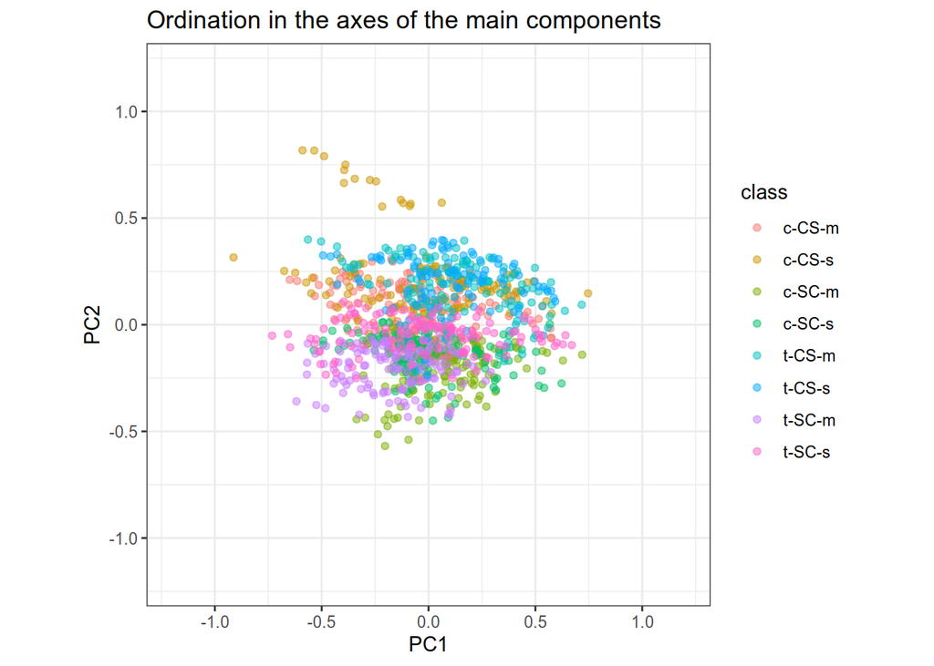

```r
# Make ordination plot:
df_scores <- data.frame(data_noNA,
                        scores(protein_pca, display = "sites", choices = c(1, 2, 3), scaling = "sites"))

p_scores <- ggplot(df_scores, aes(x = PC1, y = PC2)) +
  geom_point(aes( color = class), alpha = 0.5) +
  coord_equal(xlim = c(-1.2, 1.2), ylim = c(-1.2, 1.2)) + ggtitle(label = "Ordination in the axes of the main components") + theme_bw()
p_scores
```

```r
ord<-metaMDS(comm = data_lm, distance = "bray",autotransform = F)
```

```
## 'comm' has negative data: 'autotransform', 'noshare' and 'wascores' set to FALSE
```

```
## *** No convergence -- monoMDS stopping criteria:
##     10: stress ratio > sratmax
##     10: scale factor of the gradient < sfgrmin
```

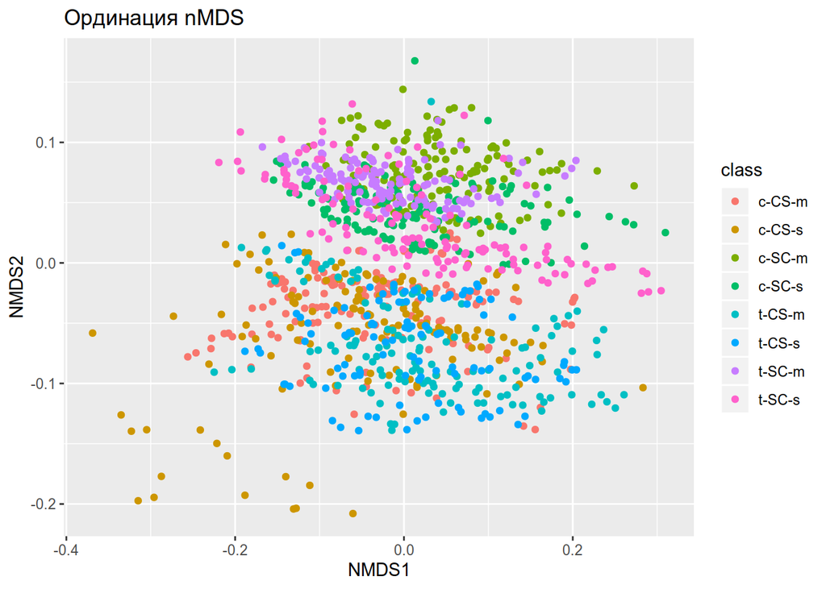

```r
ord_pt <- data.frame(data_noNA[,77], scores(ord, display = "sites"))
ggplot(ord_pt, aes(NMDS1, NMDS2, color = class))+geom_point()+ggtitle(label = "Ординация nMDS")
```

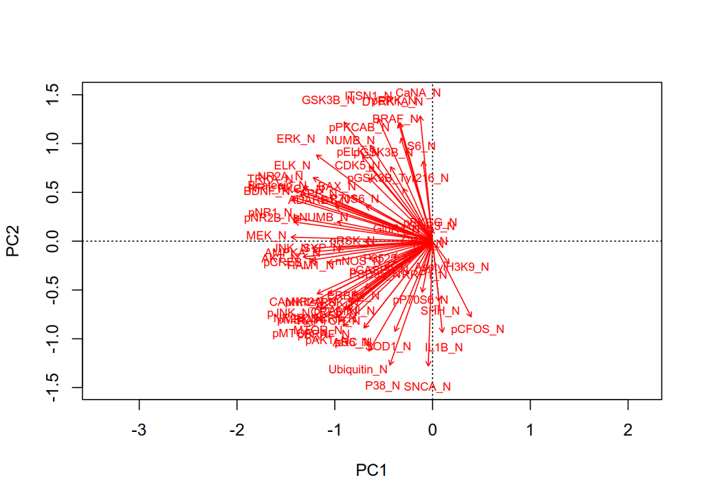

```r
# Make graphs of factor loadings
biplot(protein_pca, scaling = "species", display = "species") # факторный нагрузки
```

[figure not shown]

```r
# determine what percentage each component explains
pca_summary <- summary(protein_pca)
pca_result <- as.data.frame(pca_summary$cont)
plot_data <- as.data.frame(t(pca_result[c("Proportion Explained"),]))
plot_data$component <- rownames(plot_data)

ggplot(plot_data, aes( component, `Proportion Explained`)) + geom_bar(stat = "identity") + theme_bw()
```

```r
plot_data
```

```
##                 Proportion Explained       component
## importance.PC1          0.2701570146  importance.PC1
## importance.PC2          0.1633938089  importance.PC2
## importance.PC3          0.1088232775  importance.PC3
## importance.PC4          0.0742858449  importance.PC4
## importance.PC5          0.0492014989  importance.PC5
## importance.PC6          0.0477812688  importance.PC6
## importance.PC7          0.0344803562  importance.PC7
## importance.PC8          0.0316782524  importance.PC8
## importance.PC9          0.0236812038  importance.PC9
## importance.PC10         0.0173344172 importance.PC10
## importance.PC11         0.0151591650 importance.PC11
## importance.PC12         0.0127030300 importance.PC12
## importance.PC13         0.0113492102 importance.PC13
## importance.PC14         0.0106282136 importance.PC14
## importance.PC15         0.0090391647 importance.PC15
## importance.PC16         0.0083599832 importance.PC16
## importance.PC17         0.0080676871 importance.PC17
## importance.PC18         0.0069065057 importance.PC18
## importance.PC19         0.0060431402 importance.PC19
## importance.PC20         0.0059015637 importance.PC20
## importance.PC21         0.0057247579 importance.PC21
## importance.PC22         0.0053452882 importance.PC22
## importance.PC23         0.0049283887 importance.PC23
## importance.PC24         0.0046049473 importance.PC24
## importance.PC25         0.0040424150 importance.PC25
## importance.PC26         0.0039067724 importance.PC26
## importance.PC27         0.0035174427 importance.PC27
## importance.PC28         0.0033875786 importance.PC28
## importance.PC29         0.0031947183 importance.PC29
## importance.PC30         0.0029350622 importance.PC30
## importance.PC31         0.0024938446 importance.PC31
## importance.PC32         0.0024033774 importance.PC32
## importance.PC33         0.0023433708 importance.PC33
## importance.PC34         0.0023317011 importance.PC34
## importance.PC35         0.0020785564 importance.PC35
## importance.PC36         0.0020474834 importance.PC36
## importance.PC37         0.0018288660 importance.PC37
## importance.PC38         0.0016814433 importance.PC38
## importance.PC39         0.0016736128 importance.PC39
```

[output cut: 17 more lines]

```
## importance.PC57         0.0006624478 importance.PC57
## importance.PC58         0.0005949828 importance.PC58
## importance.PC59         0.0005535893 importance.PC59
## importance.PC60         0.0005180901 importance.PC60
## importance.PC61         0.0005105032 importance.PC61
## importance.PC62         0.0004919713 importance.PC62
## importance.PC63         0.0004457534 importance.PC63
## importance.PC64         0.0003922504 importance.PC64
## importance.PC65         0.0003614885 importance.PC65
## importance.PC66         0.0003455086 importance.PC66
## importance.PC67         0.0002792231 importance.PC67
## importance.PC68         0.0002374726 importance.PC68
## importance.PC69         0.0002158369 importance.PC69
## importance.PC70         0.0002087603 importance.PC70
## importance.PC71         0.0001559423 importance.PC71
```

Based on the load schedule, we can conclude that PC1 has negative loads for almost all proteins, while PS2 has both positive and negative loads, which are approximately evenly distributed among all proteins

```r
library(pca3d)
gr <- factor(data_noNA$class)
pca <-prcomp(data_lm, scale.=TRUE)
pca3d(pca, group=gr)
```

```
## [1] 0.3047959 0.2729918 0.1997678
## Creating new device
```

```r
snapshotPCA3d(file="first_plot.png")
```